# Case 31: Summary of Data Analysis

IC11-2 · R1, R2, R5, and R6 · Employees Federal Credit Union

Georgia Monjarrez

2026-11-04

## Data and methods

- **128 records** from the cleaned Case 31 dataset; percentages use valid responses. No imputation or weighting.
- Report rating items separately. Means and t-tests treat ratings as approximately interval.
- Two-sided tests use α = .05, with Holm correction for the four R6 tests.
- Q2 (joining reasons), Q28 (borrowing screen), and Q29 (outside borrowing reasons) are absent. R1 and R2 therefore use indirect evidence.
- The case narrative reports 123 usable questionnaires. All 128 supplied records are retained because exclusions cannot be identified.

## R1 · Descriptive statistics: rates are near average

**Question:** Why do people join the Credit Union?

Q7: 1 = very high, 2 = high, 3 = average, 4 = low, 5 = very low. “No opinion” is missing.

Table 1: Savings-rate opinions

| Response | n | Valid % |
| --- | --- | --- |
| Very high | 0 | 0.0 |
| High | 22 | 18.6 |
| Average | 83 | 70.3 |
| Low | 12 | 10.2 |
| Very low | 1 | 0.8 |

**n = 118; missing = 10; mean = 2.93; SD = 0.57.**

Most members rate savings rates as average (Table 1).

## R1 · One-sample t-test: no detected departure

The mean savings-rate rating does not differ significantly from average (one-sample t-test against 3: t(117) = -1.30, p = 0.196).

The difference from average is small (mean difference = -0.07; 95% CI [-0.17, 0.04]).

Savings-rate opinions alone cannot explain why members joined.

## R2 · Descriptive statistics: rate perceptions

**Question:** Why do members borrow from other financial institutions?

Table 2: Borrowing-rate and competitive-rate perceptions

| Item | n | Missing | Mean | SD |
| --- | --- | --- | --- | --- |
| Q8r: Credit union borrowing rates | 107 | 21 | 3.14 | 0.76 |
| Q30: Credit union rates lower than competitors | 128 | 0 | 3.06 | 0.87 |

- Q8r: **1 = very low; 3 = average; 5 = very high**. Higher scores mean higher perceived rates.
- Q30: **1 = strongly disagree; 3 = uncertain; 5 = strongly agree** that credit union loan rates are lower than competitors’. Both means are near their midpoints (Table 2).

## R2 · Frequency analysis: borrowing-rate opinions

Table 3: Borrowing-rate opinion frequencies

| Response | n | Valid % |
| --- | --- | --- |
| Very low | 1 | 0.9 |
| Low | 17 | 15.9 |
| Average | 59 | 55.1 |
| High | 26 | 24.3 |
| Very high | 4 | 3.7 |

Borrowing-rate opinions cluster around average (Table 3). Q30 agreement (4–5): **29.7%**; uncertain (3): **46.1%**; disagreement (1–2): **24.2%**.

These ratings cover all valid respondents. Without Q28–Q29, reasons for borrowing elsewhere remain unknown.

## R5 · Descriptive statistics: service awareness

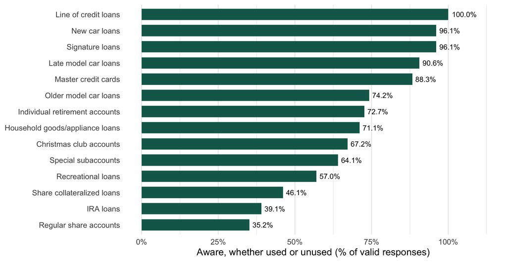

Figure 1: Percentage aware of each credit union service

## R5 · Awareness and use, services 1–7

Each cell shows **count (valid %)**. Reversed codes: 1 unaware, 2 aware but unused, 3 aware and used.

Table 4: Service awareness and use: services 1–7

| Service | Valid | Missing | Unaware | Aware, unused | Used | Aware % |
| --- | --- | --- | --- | --- | --- | --- |
| Regular share accounts | 128 | 0 | 83 (64.8%) | 32 (25.0%) | 13 (10.2%) | 35.2 |
| Special subaccounts | 128 | 0 | 46 (35.9%) | 70 (54.7%) | 12 (9.4%) | 64.1 |
| Christmas club accounts | 128 | 0 | 42 (32.8%) | 75 (58.6%) | 11 (8.6%) | 67.2 |
| Individual retirement accounts | 128 | 0 | 35 (27.3%) | 64 (50.0%) | 29 (22.7%) | 72.7 |
| Master credit cards | 128 | 0 | 15 (11.7%) | 57 (44.5%) | 56 (43.8%) | 88.3 |
| Signature loans | 128 | 0 | 5 (3.9%) | 104 (81.2%) | 19 (14.8%) | 96.1 |
| New car loans | 128 | 0 | 5 (3.9%) | 99 (77.3%) | 24 (18.8%) | 96.1 |

Aware % combines codes 2 and 3. All 14 awareness items have 128 valid responses.

## R5 · Awareness and use, services 8–14

Table 5: Service awareness and use: services 8–14

| Service | Valid | Missing | Unaware | Aware, unused | Used | Aware % |
| --- | --- | --- | --- | --- | --- | --- |
| Late model car loans | 128 | 0 | 12 (9.4%) | 102 (79.7%) | 14 (10.9%) | 90.6 |
| Older model car loans | 128 | 0 | 33 (25.8%) | 83 (64.8%) | 12 (9.4%) | 74.2 |
| Household goods/appliance loans | 128 | 0 | 37 (28.9%) | 80 (62.5%) | 11 (8.6%) | 71.1 |
| Recreational loans | 128 | 0 | 55 (43.0%) | 60 (46.9%) | 13 (10.2%) | 57.0 |
| Share collateralized loans | 128 | 0 | 69 (53.9%) | 57 (44.5%) | 2 (1.6%) | 46.1 |
| IRA loans | 128 | 0 | 78 (60.9%) | 46 (35.9%) | 4 (3.1%) | 39.1 |
| Line of credit loans | 128 | 0 | 0 (0.0%) | 80 (62.5%) | 48 (37.5%) | 100.0 |

Nonuse does not necessarily indicate dissatisfaction.

## R5 · Loan services are better known

As Figure 1, Table 4, and Table 5 show:

- Line of credit loans: **100.0% aware**; signature and new car loans: **96.1% aware** each.
- Regular share accounts: **35.2% aware**; IRA loans: **39.1% aware**; share collateralized loans: **46.1% aware**.
- Verify the unexpectedly low awareness of regular share accounts. If confirmed, prioritize explaining these accounts and less familiar loan products.

## R6 · Descriptive statistics: account information

Table 6: Statements and account information

| Measure | Count | Valid_n | Missing | Valid % |
| --- | --- | --- | --- | --- |
| Statement frequency: about right | 99 | 128 | 0 | 77.3 |
| Statement frequency: not often enough | 29 | 128 | 0 | 22.7 |
| Statements understandable: yes | 125 | 128 | 0 | 97.7 |
| Account information confidential: yes | 74 | 106 | 22 | 69.8 |

Most members find statements understandable; fewer confirm account-information confidentiality (Table 6).

Q10r accuracy: **n = 128, mean = 3.47, SD = 0.64** (1 poor–4 excellent).

Q9r = 6 − Q9 gives **M = 2.77, SD = 0.42** (1 never–5 too often). “About right” is the target, rather than a higher score.

Q11: 3 answered “No” (2.3%). Q12: 32 answered “No” (30.2% of valid responses).

## R6 · Descriptive statistics: operational ratings

Q31–Q34: 1 strongly disagree, 2 disagree, 3 uncertain, 4 agree, 5 strongly agree.

Table 7: Operational effectiveness ratings

| Item | n | Missing | Mean | SD | Agree % (4–5) | Uncertain % (3) | Disagree % (1–2) |
| --- | --- | --- | --- | --- | --- | --- | --- |
| Financial information kept confidential | 128 | 0 | 3.95 | 0.68 | 78.12 | 21.09 | 0.78 |
| Loan applications processed promptly | 128 | 0 | 3.72 | 0.79 | 60.16 | 35.16 | 4.69 |
| Services meet member needs | 128 | 0 | 3.59 | 0.68 | 59.38 | 35.16 | 5.47 |
| Loan applications simple to complete | 128 | 0 | 3.46 | 0.78 | 57.81 | 29.69 | 12.50 |

Confidentiality has the highest mean; application simplicity has the lowest (Table 7).

## R6 · One-sample t-tests: favorable ratings

All four mean ratings exceed 3, the scale midpoint. Confidence intervals below describe the **mean difference from 3**.

Table 8: One-sample tests against the midpoint of 3

| Item | Difference | CI_low | CI_high | t | df | p (unadjusted) | p (Holm) |
| --- | --- | --- | --- | --- | --- | --- | --- |
| Financial information kept confidential | 0.95 | 0.83 | 1.06 | 15.74 | 127 | < .001 | < .001 |
| Loan applications processed promptly | 0.72 | 0.58 | 0.86 | 10.25 | 127 | < .001 | < .001 |
| Services meet member needs | 0.59 | 0.47 | 0.71 | 9.87 | 127 | < .001 | < .001 |
| Loan applications simple to complete | 0.46 | 0.32 | 0.60 | 6.66 | 127 | < .001 | < .001 |

All four differences remain significant after correction for multiple tests (Holm-adjusted p < .001 each; Table 8).

The 95% intervals are individual, not simultaneous. Tests assume independent responses; findings may not generalize beyond this sample.

## R6 · Frequencies: favorable management ratings

Q37r: 1 very poor, 2 poor, 3 average, 4 good, 5 excellent.

Table 9: Overall management and operation ratings

| Response | n | Valid % |
| --- | --- | --- |
| Very poor | 1 | 0.8 |
| Poor | 2 | 1.7 |
| Average | 16 | 13.2 |
| Good | 71 | 58.7 |
| Excellent | 31 | 25.6 |

**n = 121; missing = 7. Good or excellent: 84.3%.**

Overall ratings are favorable (Table 9; M = **4.07**, SD = **0.73**).

## Conclusions and priorities

- **R1:** Savings rates are near average; joining reasons are unavailable.
- **R2:** Rate opinions are near the midpoint; outside borrowing reasons are unavailable.
- **R5:** Verify low share-account awareness before planning outreach.
- **R6:** Ratings are favorable overall. Review statement frequency and account-information confidentiality.

## Appendix

- [GitHub repository](https://github.com/gmonjarrez/case31-data-analysis)
- [Published report](https://gmonjarrez.github.io/case31-data-analysis/Monjarrez-Georgia-Case31-Summary.html)